# Assignment2

Kevin Adington

11/22/2020

# PUMS Data Analysis: % of Households with School-Aged Children without Internet Access

## Solano County

First, I selected Solano County for my Analysis in this Assignment. Below is a map utilizing PUMS/PUMA data to visualize the percentage of households with school-aged children without Internet Access. I used PUMS variables, “ACCESS” and “R18” to complete this analysis. The R18 variable, which delineates whether or not a household has any children under the age of 18, was used as a stand-in for K-12 aged children for sake of simplification.

[interactive chart not shown]

# % of Households with Children that Lack Internet Access

## Whole Bay Area

And now the analysis and mapping are shown once more over the entire Bay Area. Note the changes in color scale between the two; Solano County looks to be in relatively bad shape until put into context with other regions of the Bay Area. For the most part, Solano County is in relatively good shape as far as internet access at home for households with children, although during the COVID-19 Pandemic, this small percentage likely means that thousands of students are unable to access the internet at home and therefore may have trouble attending classes online as has been mandated state-wide since early Spring.

[interactive chart not shown]

# Educational Attainment by Race in Solano County, CA

## Bar Chart

The stacked bar chart below displays educational attainment by race. The structure would suggest that more than half of the population has at least received some college education, though the unequal sizes of bars makes it difficult to draw conclusions about proportions of race. For that, we can move on to the next figure provided below.

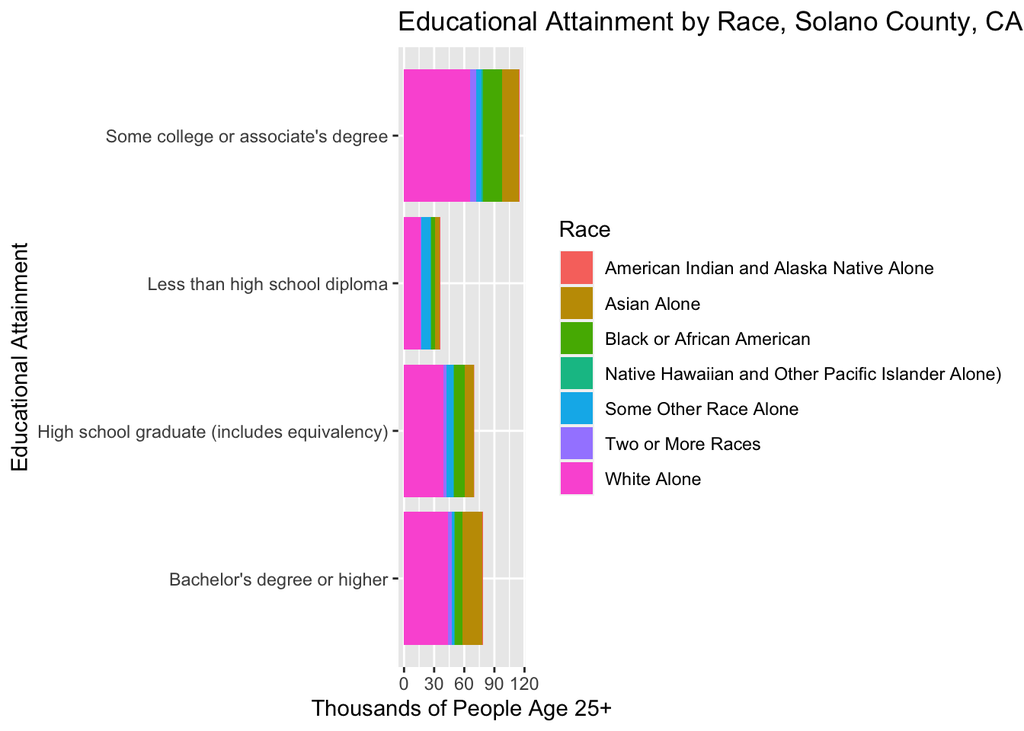

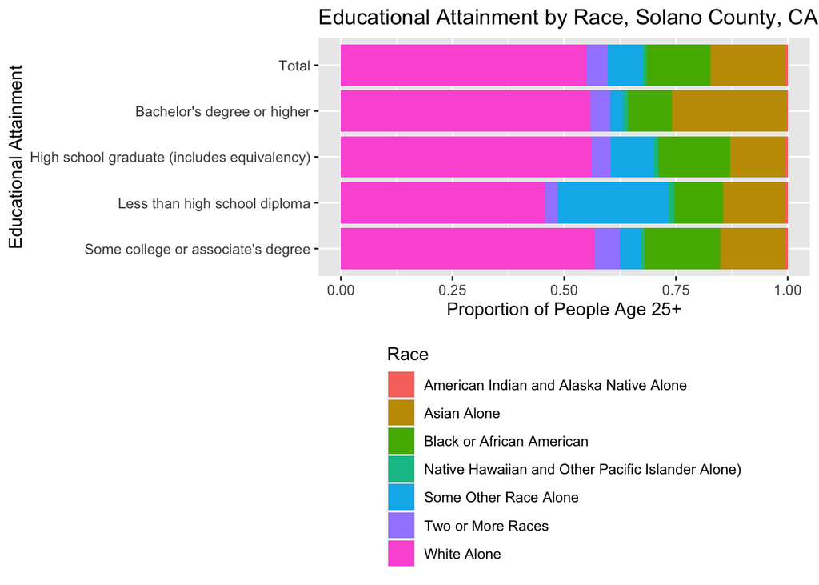

# Educational Attainment by Race in Solano County, CA

## Figure above works with proportions/percentages rather than straight-up numbers

This graph makes the realities much clearer to the viewer. Using the “Total” bar for comparison, it would seem that Asian individuals are over-represented in the pool of those who have a Bachelor’s degree of higher, and Black individuals & those of another race alone are under-represented in this same pool. This would suggest that educational attainment is not equitable in the sense that a relatively constant proportion of each race would have reached any given educational level. There any many reasons for which this may be true in the Bay Area, but these conjectures are beyond the scope of my knowledge of race in Bay Area.

```
## # A tibble: 5 x 7
##   `Educational At… `Internal net` `External net` `Here last year`
##   <chr>                     <dbl>          <dbl>            <dbl>
## 1 Bachelor's degr…         -52375         -55164           166898
## 2 Graduate or pro…         -62222         -26853           119538
## 3 High school gra…          53737         -61078            80663
## 4 Less than high …           7712         -28093            53870
## 5 Some college or…          82833         -98888           130129
## # … with 3 more variables: `Here this year` <dbl>, Outflow <dbl>, Inflow <dbl>
```

# Migration in Solano County, CA

There was a larger amount of migration out of Solano County than I had been expecting to see based on the numbers which the textbook analysis provided. That being said, educational mobility appears to be relatively healthy in the Bay Area, shown by the relatively large numbers of those with higher levels of education.